# Mini Project 3

Nii Adjetey Adjei-Annan

2024-04-12

#Problem 1 #1. Do some descriptive statistics and data visualization to explore the variables in the data.

```r
library(ggplot2)

insurance = read.csv("insurance.csv")

insurance = na.omit(insurance)

str(insurance)
```

```
## 'data.frame':    1338 obs. of  7 variables:
##  $ age     : int  19 18 28 33 32 31 46 37 37 60 ...
##  $ sex     : chr  "female" "male" "male" "male" ...
##  $ bmi     : num  27.9 33.8 33 22.7 28.9 ...
##  $ children: int  0 1 3 0 0 0 1 3 2 0 ...
##  $ smoker  : chr  "yes" "no" "no" "no" ...
##  $ region  : chr  "southwest" "southeast" "southeast" "northwest" ...
##  $ charges : num  16885 1726 4449 21984 3867 ...
```

```r
summary(insurance)
```

```
##       age            sex                 bmi           children
##  Min.   :18.00   Length:1338        Min.   :15.96   Min.   :0.000
##  1st Qu.:27.00   Class :character   1st Qu.:26.30   1st Qu.:0.000
##  Median :39.00   Mode  :character   Median :30.40   Median :1.000
##  Mean   :39.21                      Mean   :30.66   Mean   :1.095
##  3rd Qu.:51.00                      3rd Qu.:34.69   3rd Qu.:2.000
##  Max.   :64.00                      Max.   :53.13   Max.   :5.000
##     smoker             region             charges
##  Length:1338        Length:1338        Min.   : 1122
##  Class :character   Class :character   1st Qu.: 4740
##  Mode  :character   Mode  :character   Median : 9382
##                                        Mean   :13270
##                                        3rd Qu.:16640
##                                        Max.   :63770
```

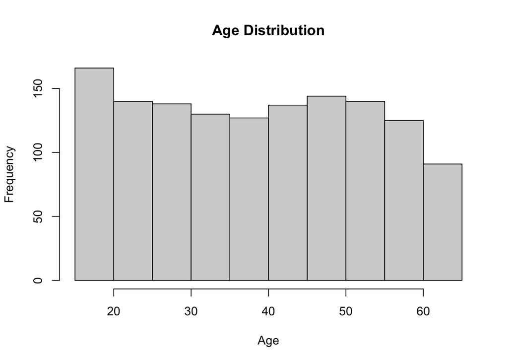

```r
# histograms for all numerical variables
hist(insurance$age, main="Age Distribution", xlab="Age")
```

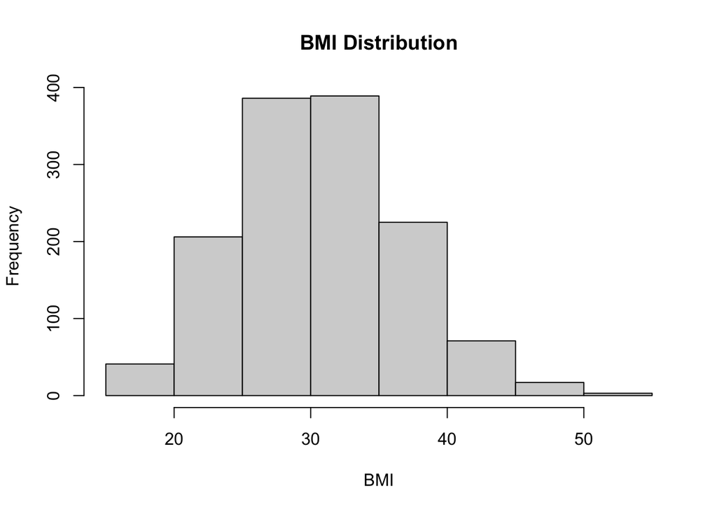

```r
hist(insurance$bmi, main="BMI Distribution", xlab="BMI")
```

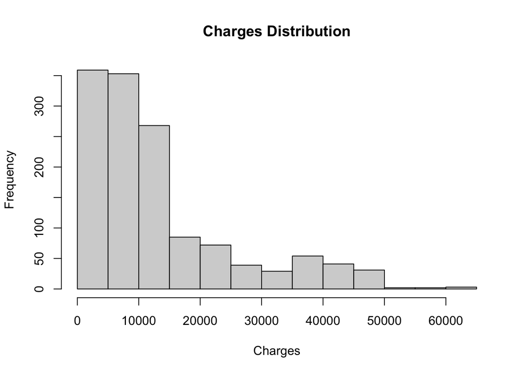

```r
hist(insurance$charges, main="Charges Distribution", xlab="Charges")
```

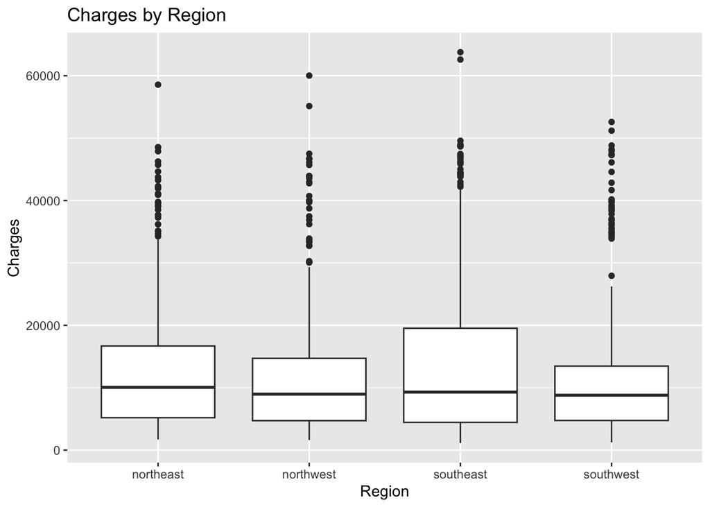

```r
# Boxplot for charges by region
ggplot(insurance, aes(x=region, y=charges)) + geom_boxplot() + xlab("Region") + ylab("Charges") + ggtitle("Charges by Region")
```

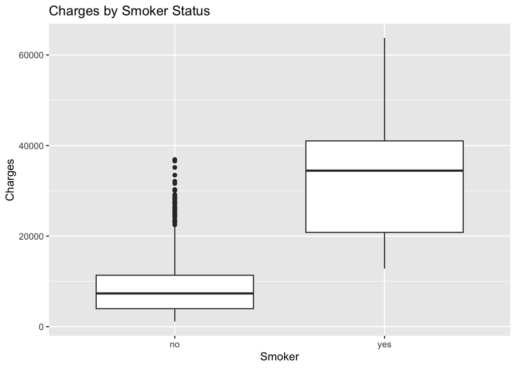

```r
# Boxplot for charges by smoker status
ggplot(insurance, aes(x=smoker, y=charges)) + geom_boxplot() + xlab("Smoker") + ylab("Charges") + ggtitle("Charges by Smoker Status")
```

```r
dim(insurance)
```

```
## [1] 1338    7
```

```r
head(insurance)
```

```
##   age    sex    bmi children smoker    region   charges
## 1  19 female 27.900        0    yes southwest 16884.924
## 2  18   male 33.770        1     no southeast  1725.552
## 3  28   male 33.000        3     no southeast  4449.462
## 4  33   male 22.705        0     no northwest 21984.471
## 5  32   male 28.880        0     no northwest  3866.855
## 6  31 female 25.740        0     no southeast  3756.622
```

```r
names(insurance)
```

```
## [1] "age"      "sex"      "bmi"      "children" "smoker"   "region"   "charges"
```

#2. Split the data into train-test data sets.

```r
set.seed(123)
dim(insurance)
```

```
## [1] 1338    7
```

```r
train_data= sample(1:1338, 0.7 * 1338)
train_data.insurance = insurance[train_data, ]
test_data.insurance = insurance[-train_data, ]
```

#3.Fit at least 3 different regression models to the train_data.insurance set using different features or different combinations of thge features

```r
# Model 1: Using age, bmi, and smoker as predictors
model1 = lm(charges ~ age + bmi + smoker, data = train_data.insurance)

# Model 2: Adding interaction between age and bmi
model2 = lm(charges ~ age * bmi + smoker, data = train_data.insurance)

# Model 3: Using all available variables and interactions
model3 = lm(charges ~ . + age:bmi + age:smoker + bmi:smoker, data = train_data.insurance)
```

#4.Find MSE of each model by applying these models to train data set, and choose a model that has the smallest MSE

```r
 # Defining MSE
calculate_mse = function(actual, predicted) {
  mse = mean((actual - predicted) ^ 2, na.rm = TRUE)
  return(mse)
}

# Predict charges using each model on the test data
predictions_model1 = predict(model1, newdata = test_data.insurance)
predictions_model2 = predict(model2, newdata = test_data.insurance)
predictions_model3 = predict(model3, newdata = test_data.insurance)

# Calculate MSE for each model
mse1 = calculate_mse(test_data.insurance$charges, predictions_model1)
mse2 = calculate_mse(test_data.insurance$charges, predictions_model2)
mse3 = calculate_mse(test_data.insurance$charges, predictions_model3)

# Print MSEs
print(c("MSE1" = mse1, "MSE2" = mse2, "MSE3" = mse3))
```

```
##     MSE1     MSE2     MSE3
## 33314292 33315412 22208356
```

```r
# Find the model with the smallest MSE
min_mse = min(mse1, mse2, mse3)
best_model_indices = which(c(mse1, mse2, mse3) == min_mse)
best_models = paste("Model", best_model_indices, collapse = ", ")
best_mse = min_mse

# Output the best model(s)
cat("The best model(s) based on the smallest MSE is(are):", best_models, "with an MSE of:", best_mse, "\n")
```

```
## The best model(s) based on the smallest MSE is(are): Model 3 with an MSE of: 22208356
```

#Problem 2 #1. Do some descriptive statistics and data visualization to explore the variables in the data.

```r
# Load necessary libraries
library(tidyverse)
# Read the data
heart_data = read.csv("heart.csv")

# Display structure and summary of the data
str(heart_data)
```

```
## 'data.frame':    303 obs. of  14 variables:
##  $ age     : int  63 37 41 56 57 57 56 44 52 57 ...
##  $ sex     : int  1 1 0 1 0 1 0 1 1 1 ...
##  $ cp      : int  3 2 1 1 0 0 1 1 2 2 ...
##  $ trtbps  : int  145 130 130 120 120 140 140 120 172 150 ...
##  $ chol    : int  233 250 204 236 354 192 294 263 199 168 ...
##  $ fbs     : int  1 0 0 0 0 0 0 0 1 0 ...
##  $ restecg : int  0 1 0 1 1 1 0 1 1 1 ...
##  $ thalachh: int  150 187 172 178 163 148 153 173 162 174 ...
##  $ exng    : int  0 0 0 0 1 0 0 0 0 0 ...
##  $ oldpeak : num  2.3 3.5 1.4 0.8 0.6 0.4 1.3 0 0.5 1.6 ...
##  $ slp     : int  0 0 2 2 2 1 1 2 2 2 ...
##  $ caa     : int  0 0 0 0 0 0 0 0 0 0 ...
##  $ thall   : int  1 2 2 2 2 1 2 3 3 2 ...
##  $ output  : int  1 1 1 1 1 1 1 1 1 1 ...
```

```r
summary(heart_data)
```

```
##       age             sex               cp            trtbps
##  Min.   :29.00   Min.   :0.0000   Min.   :0.000   Min.   : 94.0
##  1st Qu.:47.50   1st Qu.:0.0000   1st Qu.:0.000   1st Qu.:120.0
##  Median :55.00   Median :1.0000   Median :1.000   Median :130.0
##  Mean   :54.37   Mean   :0.6832   Mean   :0.967   Mean   :131.6
##  3rd Qu.:61.00   3rd Qu.:1.0000   3rd Qu.:2.000   3rd Qu.:140.0
##  Max.   :77.00   Max.   :1.0000   Max.   :3.000   Max.   :200.0
##       chol            fbs            restecg          thalachh
##  Min.   :126.0   Min.   :0.0000   Min.   :0.0000   Min.   : 71.0
##  1st Qu.:211.0   1st Qu.:0.0000   1st Qu.:0.0000   1st Qu.:133.5
##  Median :240.0   Median :0.0000   Median :1.0000   Median :153.0
##  Mean   :246.3   Mean   :0.1485   Mean   :0.5281   Mean   :149.6
##  3rd Qu.:274.5   3rd Qu.:0.0000   3rd Qu.:1.0000   3rd Qu.:166.0
##  Max.   :564.0   Max.   :1.0000   Max.   :2.0000   Max.   :202.0
##       exng           oldpeak          slp             caa
##  Min.   :0.0000   Min.   :0.00   Min.   :0.000   Min.   :0.0000
##  1st Qu.:0.0000   1st Qu.:0.00   1st Qu.:1.000   1st Qu.:0.0000
##  Median :0.0000   Median :0.80   Median :1.000   Median :0.0000
##  Mean   :0.3267   Mean   :1.04   Mean   :1.399   Mean   :0.7294
##  3rd Qu.:1.0000   3rd Qu.:1.60   3rd Qu.:2.000   3rd Qu.:1.0000
##  Max.   :1.0000   Max.   :6.20   Max.   :2.000   Max.   :4.0000
##      thall           output
##  Min.   :0.000   Min.   :0.0000
##  1st Qu.:2.000   1st Qu.:0.0000
##  Median :2.000   Median :1.0000
##  Mean   :2.314   Mean   :0.5446
##  3rd Qu.:3.000   3rd Qu.:1.0000
##  Max.   :3.000   Max.   :1.0000
```

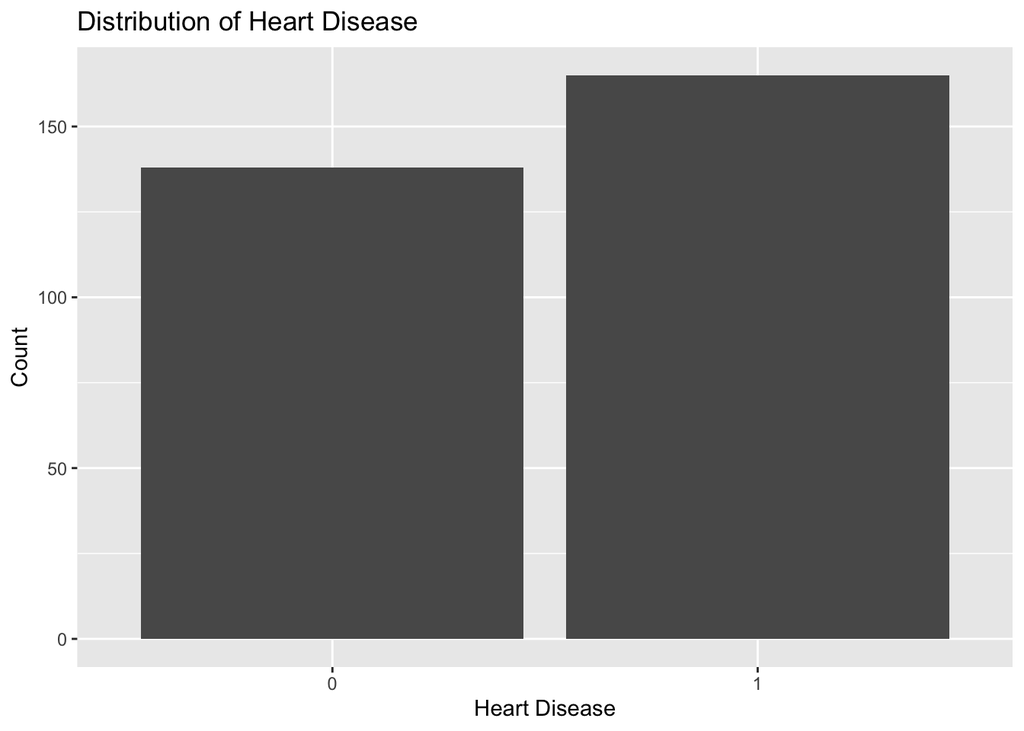

```r
# Create plots for variable distribution
ggplot(heart_data, aes(x = factor(output))) + geom_bar() + labs(title = "Distribution of Heart Disease", x = "Heart Disease", y = "Count")
```

```r
names(heart_data)
```

```
##  [1] "age"      "sex"      "cp"       "trtbps"   "chol"     "fbs"
##  [7] "restecg"  "thalachh" "exng"     "oldpeak"  "slp"      "caa"
## [13] "thall"    "output"
```

#2 Split the data into train-test data sets.

```r
set.seed(123)
dim(heart_data)
```

```
## [1] 303  14
```

```r
train_indices = sample(1:303, 0.8 * 303)
train_set = heart_data[train_indices, ]
test_set = heart_data[-train_indices, ]

dim(train_set)
```

```
## [1] 242  14
```

```r
dim(test_set)
```

```
## [1] 61 14
```

#3 Fit the 3 methods for classification we have studied: Logistic Regression Model,K-nearest neighbor classifier and Naive Bayes Classifier to the train dataset.

```r
# Logistic Regression
library(stats)
log_model = glm(output ~ ., family = binomial, data = train_set)
summary(log_model)
```

```
##
## Call:
## glm(formula = output ~ ., family = binomial, data = train_set)
##
## Coefficients:
##              Estimate Std. Error z value Pr(>|z|)
## (Intercept)  4.555347   2.794683   1.630  0.10310
## age         -0.013283   0.025289  -0.525  0.59941
## sex         -1.540661   0.509861  -3.022  0.00251 **
## cp           0.769378   0.195309   3.939 8.17e-05 ***
## trtbps      -0.017916   0.011003  -1.628  0.10348
## chol        -0.003182   0.004177  -0.762  0.44617
## fbs          0.132748   0.566248   0.234  0.81465
## restecg      0.658516   0.389009   1.693  0.09049 .
## thalachh     0.019761   0.011439   1.727  0.08408 .
## exng        -1.077694   0.448609  -2.402  0.01629 *
## oldpeak     -0.678520   0.240961  -2.816  0.00486 **
## slp          0.263729   0.411859   0.640  0.52195
## caa         -0.646435   0.201346  -3.211  0.00132 **
## thall       -1.015510   0.330194  -3.075  0.00210 **
## ---
## Signif. codes:  0 '***' 0.001 '**' 0.01 '*' 0.05 '.' 0.1 ' ' 1
##
## (Dispersion parameter for binomial family taken to be 1)
##
##     Null deviance: 333.48  on 241  degrees of freedom
## Residual deviance: 173.07  on 228  degrees of freedom
## AIC: 201.07
##
## Number of Fisher Scoring iterations: 6
```

```r
# K-Nearest Neighbors
library(class)
knn_model = knn(train = train_set[, -ncol(train_set)], test = test_set[, -ncol(train_set)], cl = train_set$output, k = 5)
summary(knn_model)
```

```
##  0  1
## 27 34
```

```r
# Naive Bayes
library(e1071)
nb_model = naiveBayes(output ~ ., data = train_set)
summary(nb_model)
```

```
##           Length Class  Mode
## apriori    2     table  numeric
## tables    13     -none- list
## levels     2     -none- character
## isnumeric 13     -none- logical
## call       4     -none- call
```

#4 Apply the fitted methods to the train data set.

```r
# Logistic Regression predictions
log_pred = predict(log_model, train_set, type = "response")
log_pred_class = ifelse(log_pred > 0.5, 1, 0)

# K-NN Predictions
knn_pred = knn(train = train_set[, -ncol(train_set)], test = train_set[, -ncol(train_set)], cl = train_set$output, k = 5)

# Naive Bayes predictions
nb_pred = predict(nb_model, train_set)
```

#5 Find the following for each: TPR,TNR,FPR,FNR and Accuracy for each. For better perfor- mance, TPR, TNR,ACC should be high and FNR, FPR should be low.

```r
calculate_metrics = function(predictions, actual) {
  if(length(predictions) != length(actual)) {
    stop("Length of predictions does not match length of actual data")
  }
  cm = table(Predicted = predictions, Actual = actual)
  tpr = cm[2,2] / (cm[2,2] + cm[2,1])
  tnr = cm[1,1] / (cm[1,1] + cm[1,2])
  fpr = cm[1,2] / (cm[1,1] + cm[1,2])
  fnr = cm[2,1] / (cm[2,2] + cm[2,1])
  acc = (cm[1,1] + cm[2,2]) / sum(cm)
  return(c(TPR = tpr, TNR = tnr, FPR = fpr, FNR = fnr, ACC = acc))
}

# Computing metrics for each model
log_metrics = calculate_metrics(log_pred_class, train_set$output)
print("Logistic Regression Metrics:")
```

```
## [1] "Logistic Regression Metrics:"
```

```r
print(log_metrics)
```

```
##       TPR       TNR       FPR       FNR       ACC
## 0.8391608 0.8787879 0.1212121 0.1608392 0.8553719
```

```r
knn_metrics = calculate_metrics(as.numeric(knn_pred) - 1, train_set$output)  # Ensure conversion and alignment
print("K-Nearest Neighbors Metrics:")
```

```
## [1] "K-Nearest Neighbors Metrics:"
```

```r
print(knn_metrics)
```

```
##       TPR       TNR       FPR       FNR       ACC
## 0.7801418 0.7821782 0.2178218 0.2198582 0.7809917
```

```r
nb_metrics = calculate_metrics(as.numeric(nb_pred), train_set$output)
print("Naive Bayes Metrics:")
```

```
## [1] "Naive Bayes Metrics:"
```

```r
print(nb_metrics)
```

```
##       TPR       TNR       FPR       FNR       ACC
## 0.8333333 0.8365385 0.1634615 0.1666667 0.8347107
```

#6. Draw a ROC Curves on the same plot.

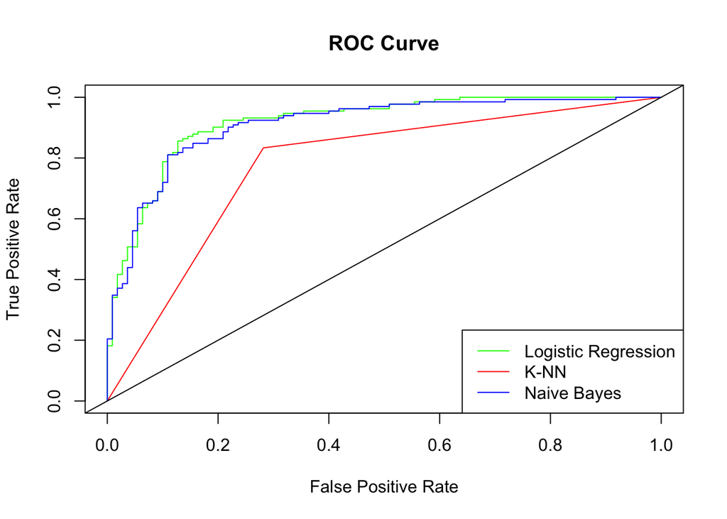

```r
# Load the ROCR library
library(ROCR)

# Predictions for logistic regression
log_pred_probs = predict(log_model, train_set, type = "response")
log_pred = prediction(log_pred_probs, train_set$output)

# Predictions for K-Nearest Neighbors
knn_pred_probs = as.numeric(knn_pred) - 1
knn_pred = prediction(knn_pred_probs, train_set$output)

# Predictions for Naive Bayes
nb_pred_probs = predict(nb_model, train_set, type = "raw")[,2]
nb_pred = prediction(nb_pred_probs, train_set$output)

# Performance calculations for TPR and FPR
log_perf = performance(log_pred, "tpr", "fpr")
knn_perf = performance(knn_pred, "tpr", "fpr")
nb_perf = performance(nb_pred, "tpr", "fpr")

# Plotting the ROC curves
plot(log_perf, col = "green", main = "ROC Curve", xlab = "False Positive Rate", ylab = "True Positive Rate")
plot(knn_perf, col = "red", add = TRUE)
plot(nb_perf, col = "blue", add = TRUE)
legend("bottomright", legend = c("Logistic Regression", "K-NN", "Naive Bayes"), col = c("green", "red", "blue"), lty = 1)
abline(0, 1, col = "black", lwd = 1)  # Adding a line of no discrimination
```

#7.Find the method that works best on this data set.

```r
#[1] "Logistic Regression Metrics:"
 #     TPR       TNR       FPR       FNR       ACC
#0.8391608 0.8787879 0.1212121 0.1608392 0.8553719
#[1] "K-Nearest Neighbors Metrics:"
 #     TPR       TNR       FPR       FNR       ACC
#0.7801418 0.7821782 0.2178218 0.2198582 0.7809917
#[1] "Naive Bayes Metrics:"
 #     TPR       TNR       FPR       FNR       ACC
#0.8333333 0.8365385 0.1634615 0.1666667 0.8347107

# The logisitc regression method has the best performancw metrics. Among all the other methods, it has highest ACC TPR AND TNR. It also has the lowest FNR. Also, it has an ROC curve that is closer to 1, showing best performance.
```